# Untitled

2024-11-25

# Lectura de dades

```r
dades<-read.csv2("./SOLER CARBALLO, Àlex.csv",header=T,stringsAsFactors = TRUE)
```

- Utilitzar residuos deviancia que son els que utilitza R per defecte
- Utilitzar l’estimació de Pearson per al paràmetre de dispersió que és el que utilitza R per defecte
- La variable x és una covariable, però com que a cada valor de la x hi ha repeticions de la y , ocasionalment també es pot utilitzar la x com a factor per poder contrastar alguns tests, com el de Levene o el test de comparar el model que tenim amb el model resultat de afegir-hi x com a factor. Aquests tests us poden ser útils per analitzar el comportament dels models del vostre exercici.

# A. Plantegeu, ajusteu i analitzeu el model Mod1

```r
mod1<-glm(y ~ log(x), family=gaussian(link="log"),dades)
summary(mod1)
```

```
##
## Call:
## glm(formula = y ~ log(x), family = gaussian(link = "log"), data = dades)
##
## Coefficients:
##             Estimate Std. Error t value Pr(>|t|)
## (Intercept)  -4.1914     0.7527  -5.568 1.64e-07 ***
## log(x)        1.8247     0.1548  11.784  < 2e-16 ***
## ---
## Signif. codes:  0 '***' 0.001 '**' 0.01 '*' 0.05 '.' 0.1 ' ' 1
##
## (Dispersion parameter for gaussian family taken to be 867.6243)
##
##     Null deviance: 304776  on 119  degrees of freedom
## Residual deviance: 102380  on 118  degrees of freedom
## AIC: 1156.4
##
## Number of Fisher Scoring iterations: 6
```

## 1) La deviància ha donat

```r
signif(summary(mod1)$deviance,5)
```

```
## [1] 102380
```

## 2) Escollir opció correcte

```r
library(car)
dades2<-dades
dades2$xlog<-log(dades2$x)
dades2$x<-as.factor(dades2$x)
dades2$xlog<-as.factor(dades2$xlog)
mod1fac<-glm(y ~ xlog, family=gaussian(link="log"),dades2)
anova(mod1,mod1fac,test="F")
```

```
## Analysis of Deviance Table
##
## Model 1: y ~ log(x)
## Model 2: y ~ xlog
##   Resid. Df Resid. Dev Df Deviance      F  Pr(>F)
## 1       118     102380
## 2       114      92113  4    10267 3.1765 0.01626 *
## ---
## Signif. codes:  0 '***' 0.001 '**' 0.01 '*' 0.05 '.' 0.1 ' ' 1
```

4. Estem segurs que el model no ajusta bé les dades

## 3) Escolliu l’opció correcte

```r
leveneTest(resid(mod1fac,type="deviance"), dades2$xlog)
```

```
## Levene's Test for Homogeneity of Variance (center = median)
##        Df F value    Pr(>F)
## group   5  11.578 4.694e-09 ***
##       114
## ---
## Signif. codes:  0 '***' 0.001 '**' 0.01 '*' 0.05 '.' 0.1 ' ' 1
```

Surten que les variancies no son iguals, per tant, variancia no constant

4. Estem segurs que Mod1 no compleix la funció de variància

# B. Plantegeu, ajusteu i analitzeu el model Mod2

```r
mod2<-glm(y ~ x, family=gaussian(link=inverse),dades)
summary(mod2)
```

```
##
## Call:
## glm(formula = y ~ x, family = gaussian(link = inverse), data = dades)
##
## Coefficients:
##               Estimate Std. Error t value Pr(>|t|)
## (Intercept)  3.725e-02  2.766e-03   13.47   <2e-16 ***
## x           -2.048e-04  1.901e-05  -10.78   <2e-16 ***
## ---
## Signif. codes:  0 '***' 0.001 '**' 0.01 '*' 0.05 '.' 0.1 ' ' 1
##
## (Dispersion parameter for gaussian family taken to be 859.7642)
##
##     Null deviance: 304776  on 119  degrees of freedom
## Residual deviance: 101452  on 118  degrees of freedom
## AIC: 1155.3
##
## Number of Fisher Scoring iterations: 6
```

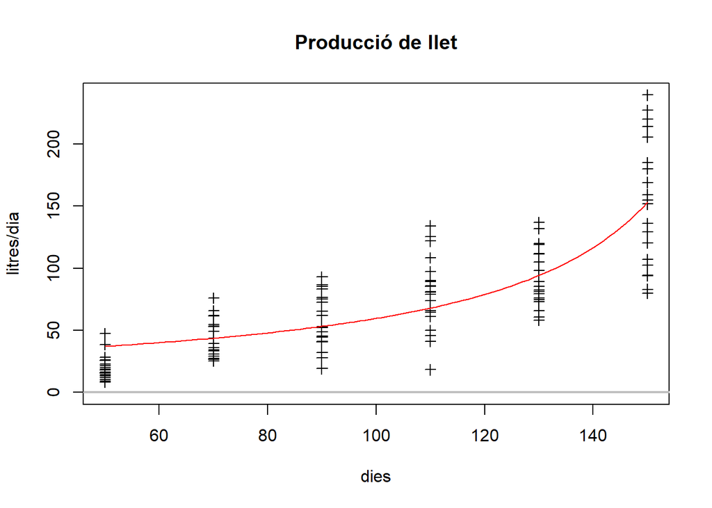

```r
X  <- 50:150
pprod <- predict(mod2, data.frame(x=X), type="response")

plot(y ~ x, dades, pch=3,ylim=c(0,max(pprod,dades$y)),
     xlab="dies",ylab="litres/dia",
     main="Producció de llet")
lines(X,pprod,col="red")
abline(h=0,col="gray",lwd=2)
```

## 4) L’estadístic de dispersió ha donat

```r
signif(summary(mod2)$dispersion,5)
```

```
## [1] 859.76
```

## 5) Escolliu opció correcte

```r
mod2fac<-glm(y ~ x, family=gaussian(link=inverse),dades2)
anova(mod2,mod2fac,test="F")
```

```
## Analysis of Deviance Table
##
## Model 1: y ~ x
## Model 2: y ~ x
##   Resid. Df Resid. Dev Df Deviance      F  Pr(>F)
## 1       118     101452
## 2       114      92113  4     9339 2.8895 0.02542 *
## ---
## Signif. codes:  0 '***' 0.001 '**' 0.01 '*' 0.05 '.' 0.1 ' ' 1
```

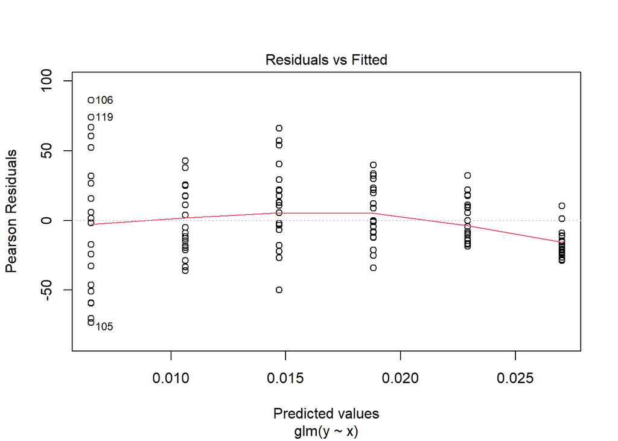

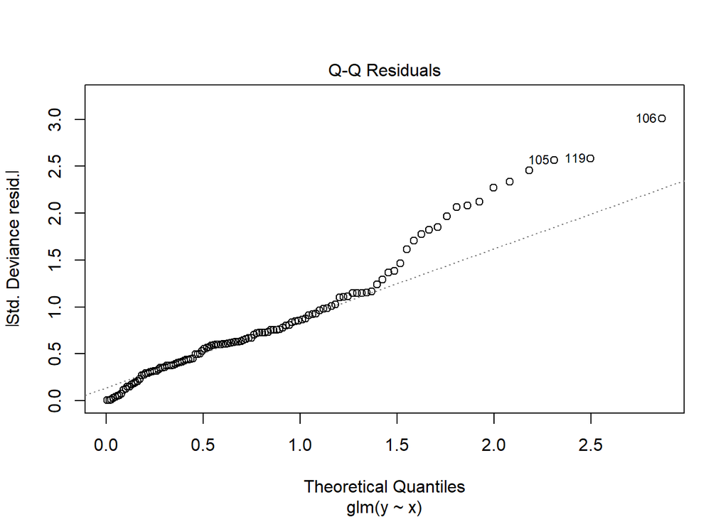

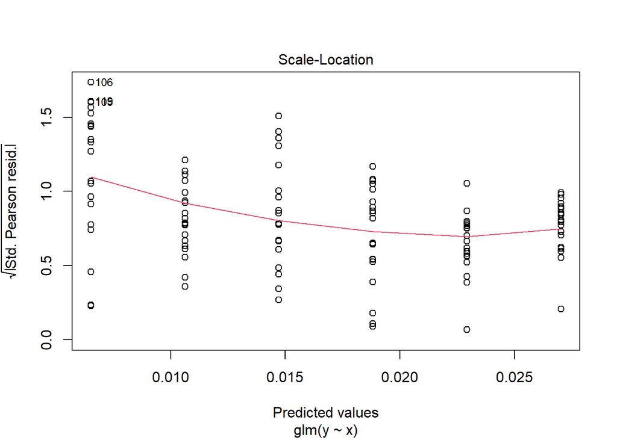

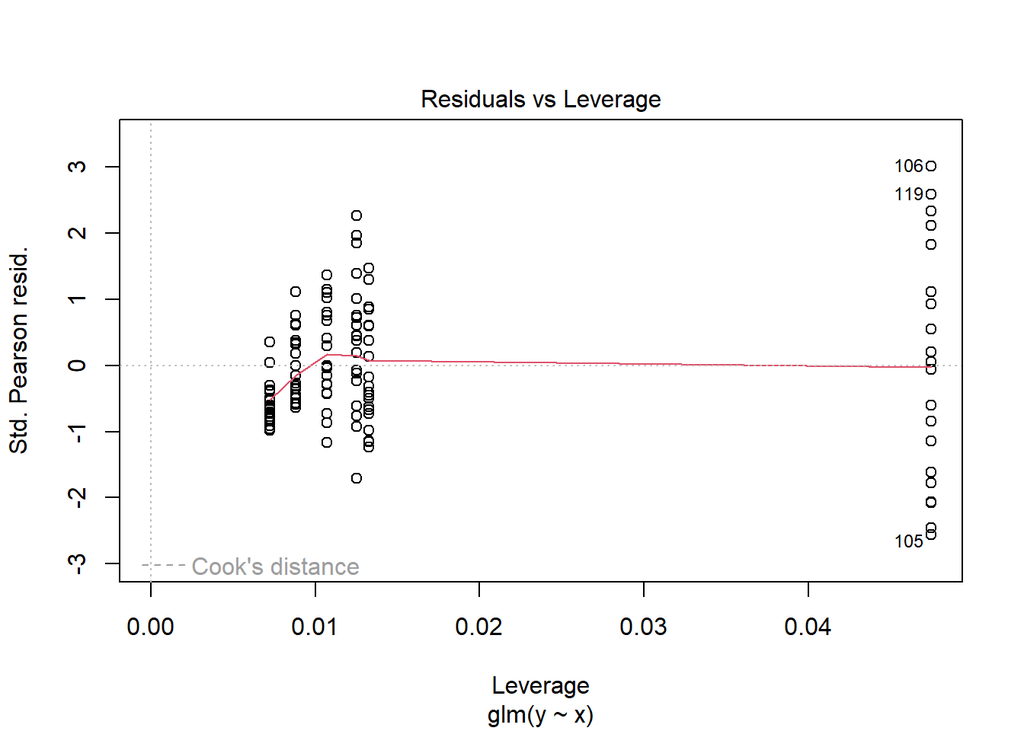

```r
plot(mod2)
```

d) Estem segurs que Mod2 no ajusta bé les dades

## 6) Escolliu opció correcte

```r
leveneTest(resid(mod2fac),dades2$x)
```

```
## Levene's Test for Homogeneity of Variance (center = median)
##        Df F value    Pr(>F)
## group   5  11.578 4.694e-09 ***
##       114
## ---
## Signif. codes:  0 '***' 0.001 '**' 0.01 '*' 0.05 '.' 0.1 ' ' 1
```

4. Estem segur que Mod2 no compleix la funció de variancia

# C) Plantegeu, ajusteu i analitzeu el model mod3

```r
mod3<-glm(y ~ log(x), family=Gamma(link="log"),dades)
summary(mod3)
```

```
##
## Call:
## glm(formula = y ~ log(x), family = Gamma(link = "log"), data = dades)
##
## Coefficients:
##             Estimate Std. Error t value Pr(>|t|)
## (Intercept) -3.55887    0.42052  -8.463 8.24e-14 ***
## log(x)       1.69295    0.09232  18.339  < 2e-16 ***
## ---
## Signif. codes:  0 '***' 0.001 '**' 0.01 '*' 0.05 '.' 0.1 ' ' 1
##
## (Dispersion parameter for Gamma family taken to be 0.1424048)
##
##     Null deviance: 60.017  on 119  degrees of freedom
## Residual deviance: 17.399  on 118  degrees of freedom
## AIC: 1090.8
##
## Number of Fisher Scoring iterations: 4
```

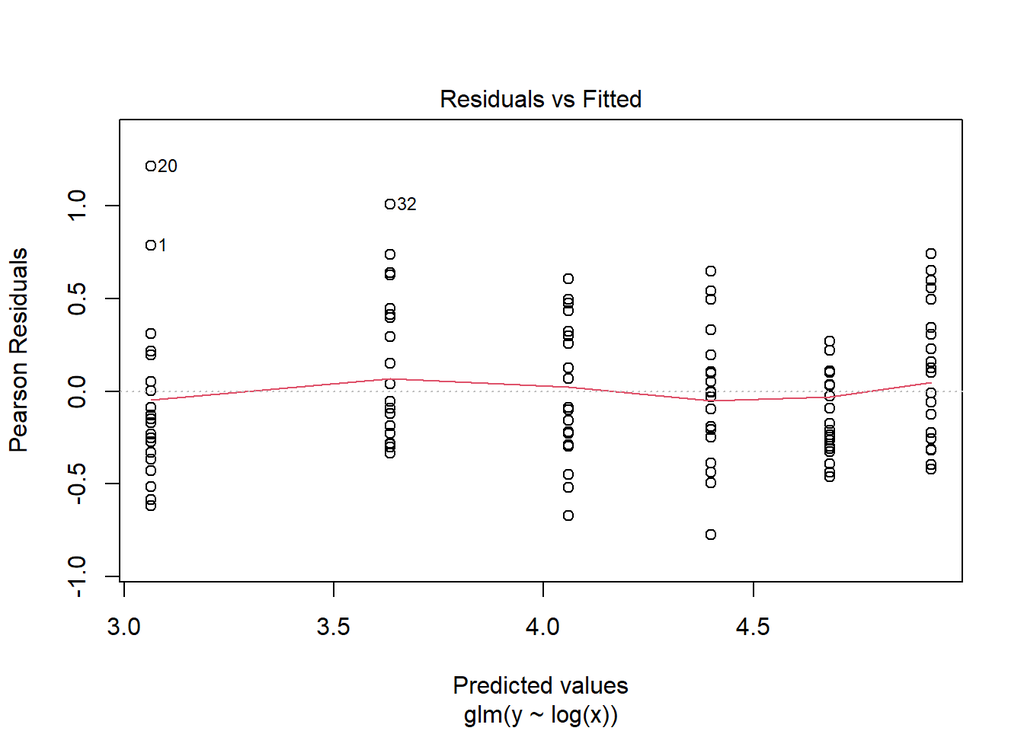

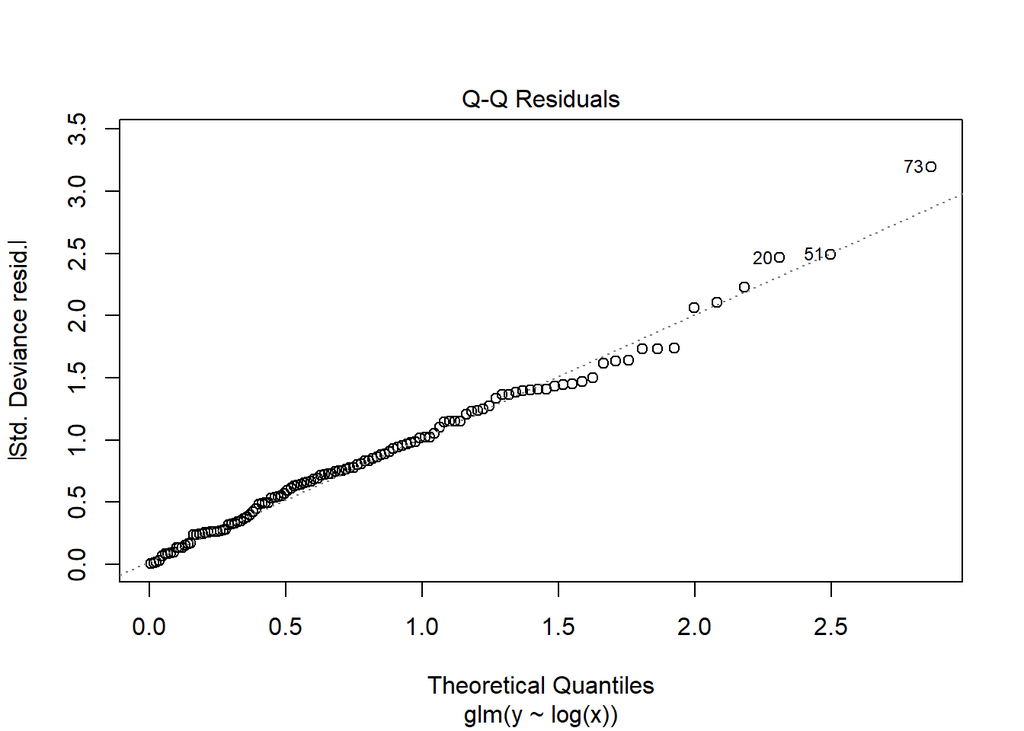

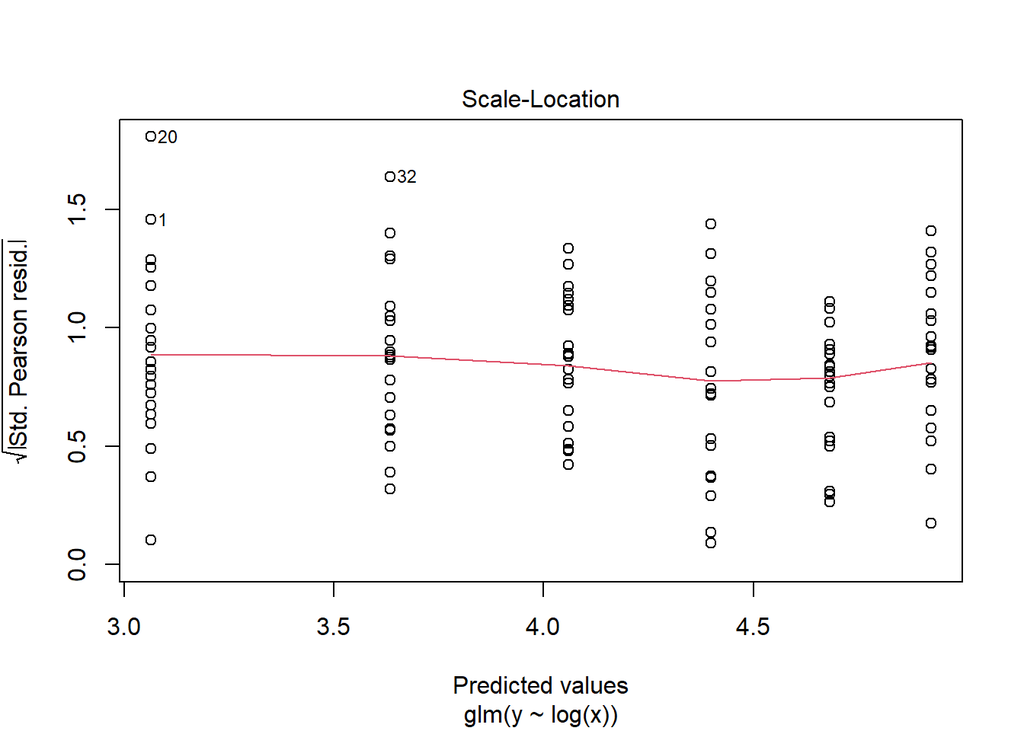

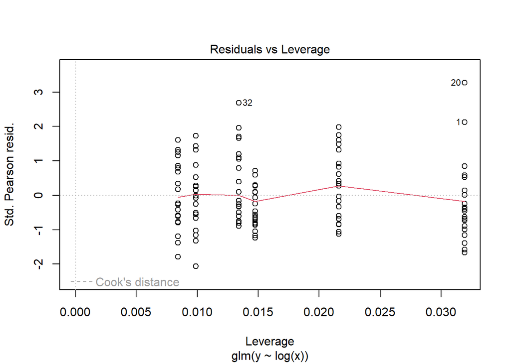

```r
plot(mod3)
```

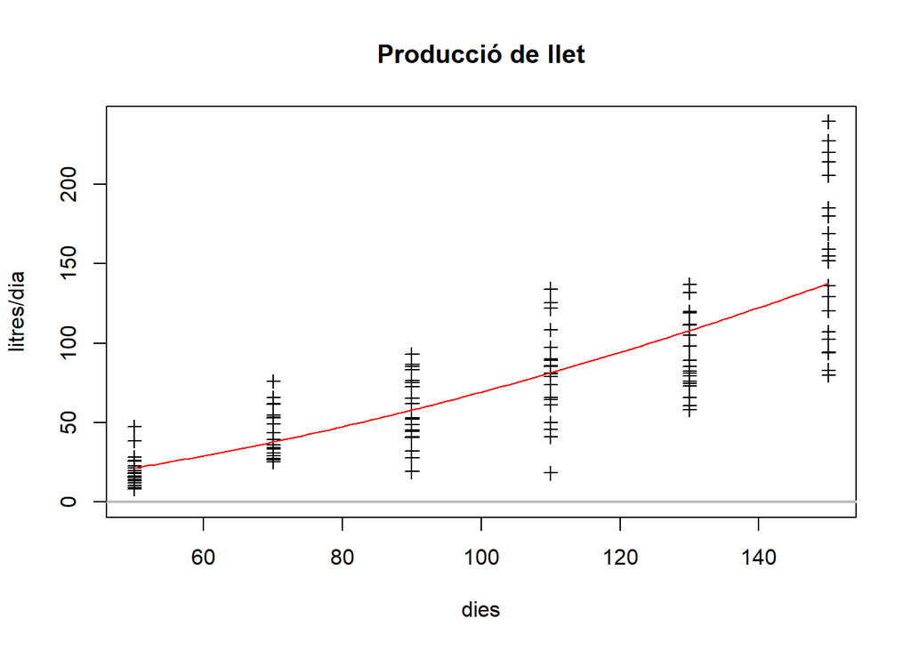

```r
X  <- 50:150
pprod <- predict(mod3, data.frame(x=X), type="response")

plot(y ~ x, dades, pch=3,ylim=c(0,max(pprod,dades$y)),
     xlab="dies",ylab="litres/dia",
     main="Producció de llet")
lines(X,pprod,col="red")
abline(h=0,col="gray",lwd=2)
```

## 7) L’intercept ha donat

```r
signif(summary(mod3)$coef[1,1],5)
```

```
## [1] -3.5589
```

## 8) Escolliu l’opció correcte

```r
mod3fac<-glm(y ~ xlog, family=Gamma(link="log"),dades2)
anova(mod3,mod3fac,test="F")
```

```
## Analysis of Deviance Table
##
## Model 1: y ~ log(x)
## Model 2: y ~ xlog
##   Resid. Df Resid. Dev Df Deviance      F  Pr(>F)
## 1       118     17.399
## 2       114     16.175  4   1.2238 2.2526 0.06774 .
## ---
## Signif. codes:  0 '***' 0.001 '**' 0.01 '*' 0.05 '.' 0.1 ' ' 1
```

## 9) Escolliu l’opció correcte

```r
leveneTest(resid(mod3fac),dades2$xlog)
```

```
## Levene's Test for Homogeneity of Variance (center = median)
##        Df F value Pr(>F)
## group   5  0.5628 0.7283
##       114
```

# D) Plantegeu, ajusteu i analitzeu el model mod4

```r
mod4<-glm(y ~ x, family=Gamma(link=inverse),dades)
summary(mod4)
```

```
##
## Call:
## glm(formula = y ~ x, family = Gamma(link = inverse), data = dades)
##
## Coefficients:
##               Estimate Std. Error t value Pr(>|t|)
## (Intercept)  4.168e-02  2.364e-03   17.63   <2e-16 ***
## x           -2.374e-04  1.735e-05  -13.69   <2e-16 ***
## ---
## Signif. codes:  0 '***' 0.001 '**' 0.01 '*' 0.05 '.' 0.1 ' ' 1
##
## (Dispersion parameter for Gamma family taken to be 0.1722239)
##
##     Null deviance: 60.017  on 119  degrees of freedom
## Residual deviance: 22.557  on 118  degrees of freedom
## AIC: 1122.8
##
## Number of Fisher Scoring iterations: 5
```

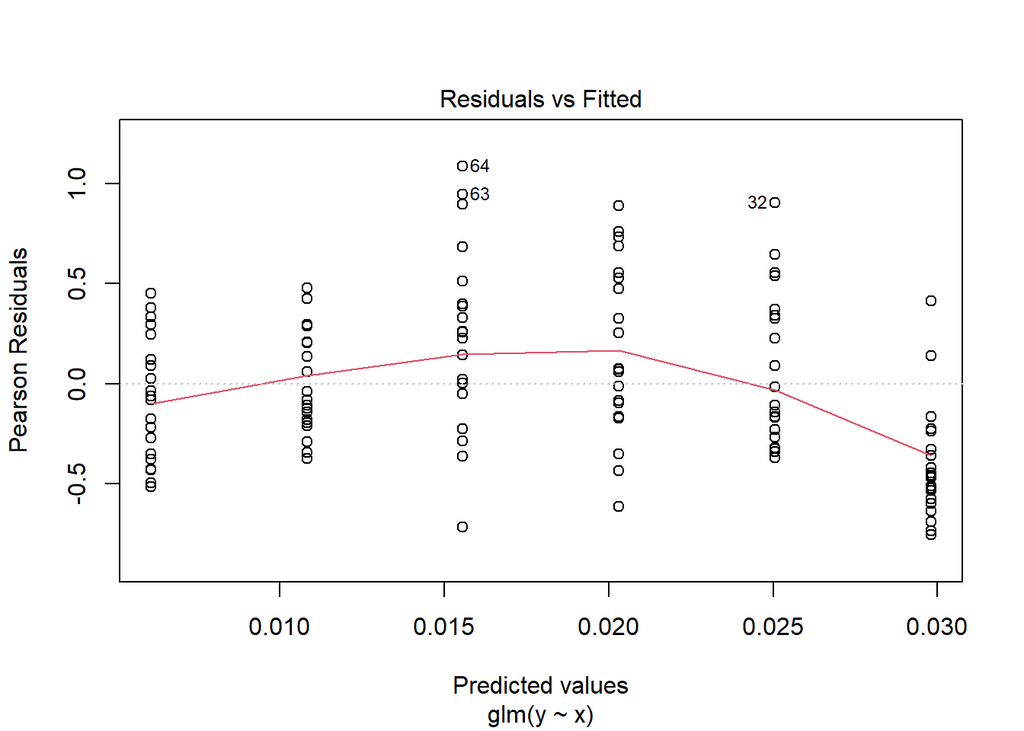

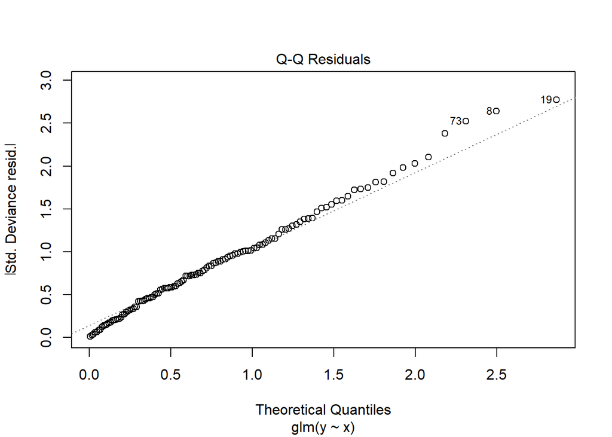

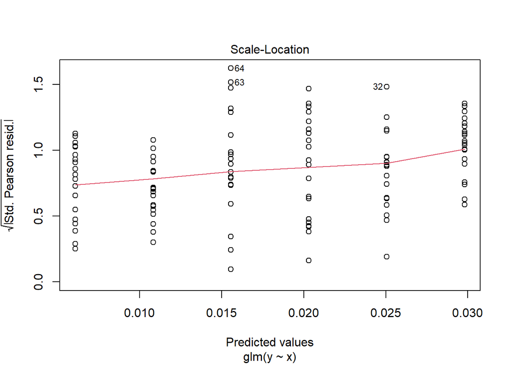

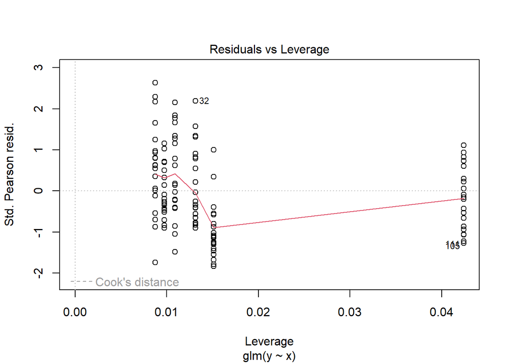

```r
plot(mod4)
```

## 10) L’error estàndard del coeficient de la covariable ha donat

```r
signif(summary(mod4)$coef[2,2],5)
```

```
## [1] 1.7345e-05
```

## 11) Escolliu l’opció correcte

```r
mod4fac<-glm(y ~ x, family=Gamma(link=inverse),dades2)
anova(mod4,mod4fac,test="F")
```

```
## Analysis of Deviance Table
##
## Model 1: y ~ x
## Model 2: y ~ x
##   Resid. Df Resid. Dev Df Deviance      F    Pr(>F)
## 1       118     22.557
## 2       114     16.175  4   6.3813 11.746 5.052e-08 ***
## ---
## Signif. codes:  0 '***' 0.001 '**' 0.01 '*' 0.05 '.' 0.1 ' ' 1
```

## 12) Escolliu l’opció correcte

```r
leveneTest(resid(mod4fac),dades2$x)
```

```
## Levene's Test for Homogeneity of Variance (center = median)
##        Df F value Pr(>F)
## group   5  0.5628 0.7283
##       114
```

# E) Plantegeu, ajusteu i analitzeu el model mod5

```r
mod5<-glm(y ~ x, family=inverse.gaussian(link=inverse),dades)
summary(mod5)
```

```
##
## Call:
## glm(formula = y ~ x, family = inverse.gaussian(link = inverse),
##     data = dades)
##
## Coefficients:
##               Estimate Std. Error t value Pr(>|t|)
## (Intercept)  4.584e-02  2.528e-03   18.14   <2e-16 ***
## x           -2.725e-04  2.006e-05  -13.59   <2e-16 ***
## ---
## Signif. codes:  0 '***' 0.001 '**' 0.01 '*' 0.05 '.' 0.1 ' ' 1
##
## (Dispersion parameter for inverse.gaussian family taken to be 0.003885448)
##
##     Null deviance: 1.21020  on 119  degrees of freedom
## Residual deviance: 0.60012  on 118  degrees of freedom
## AIC: 1170.3
##
## Number of Fisher Scoring iterations: 2
```

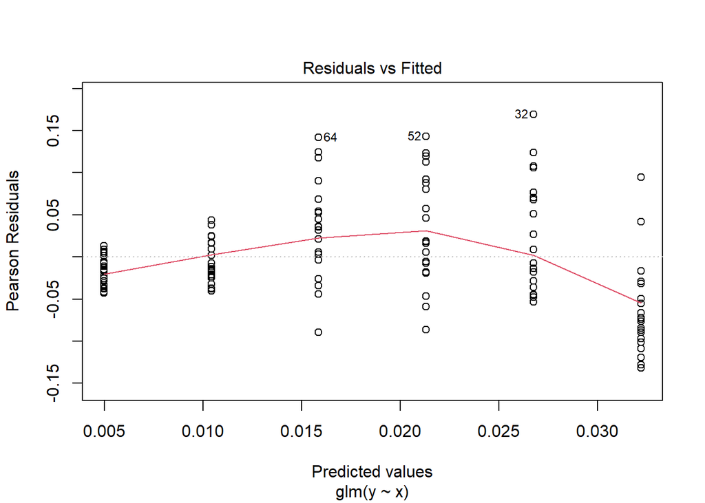

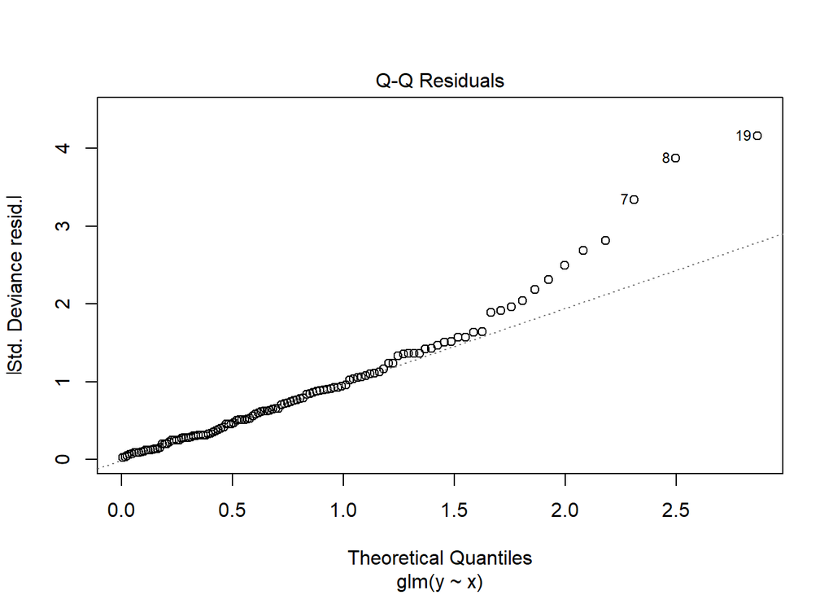

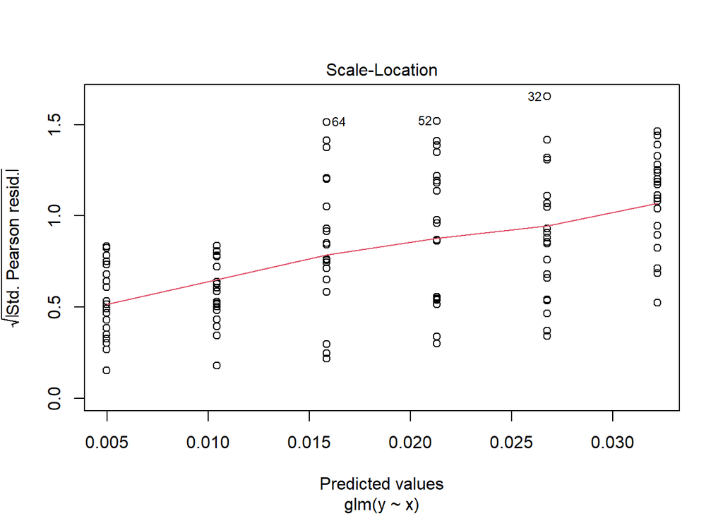

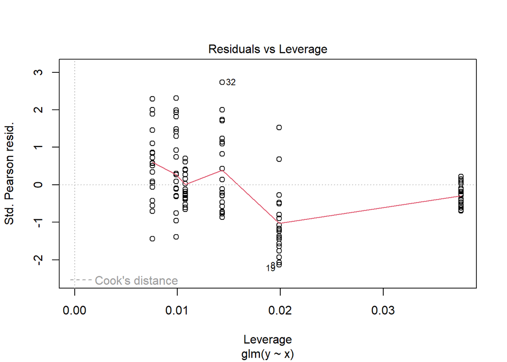

```r
plot(mod5)
```

## 13) La deviància del model nul ha donat

```r
signif(summary(mod5)$null.deviance,5)
```

```
## [1] 1.2102
```

## 14) Escolliu l’opció correcte

```r
mod5fac<-glm(y ~ x, family=inverse.gaussian(link=inverse),dades2)
anova(mod5,mod5fac,test="F")
```

```
## Analysis of Deviance Table
##
## Model 1: y ~ x
## Model 2: y ~ x
##   Resid. Df Resid. Dev Df Deviance      F   Pr(>F)
## 1       118    0.60012
## 2       114    0.41655  4  0.18357 13.592 4.31e-09 ***
## ---
## Signif. codes:  0 '***' 0.001 '**' 0.01 '*' 0.05 '.' 0.1 ' ' 1
```

## 15) Escolliu l’opció correcte

```r
leveneTest(resid(mod5fac),dades2$x)
```

```
## Levene's Test for Homogeneity of Variance (center = median)
##        Df F value    Pr(>F)
## group   5  5.4657 0.0001515 ***
##       114
## ---
## Signif. codes:  0 '***' 0.001 '**' 0.01 '*' 0.05 '.' 0.1 ' ' 1
```

# F) Compareu els 5 models anteriors

## 16) Quin valor té la log-versemblança més alta dels 5 models

```r
lk<-c(as.numeric(logLik(mod1)),as.numeric(logLik(mod2)),as.numeric(logLik(mod3)),as.numeric(logLik(mod4)),as.numeric(logLik(mod5)))
lk
```

```
## [1] -575.2097 -574.6636 -542.3796 -558.3850 -582.1693
```

```r
signif(max(lk),5) #mod3
```

```
## [1] -542.38
```

## 17) En quin model hem obtingut R^2 més elevat

```r
(summary(mod1)$null.deviance-summary(mod1)$deviance)/summary(mod1)$null.deviance
```

```
## [1] 0.6640823
```

```r
(summary(mod2)$null.deviance-summary(mod2)$deviance)/summary(mod2)$null.deviance
```

```
## [1] 0.6671257
```

```r
(summary(mod3)$null.deviance-summary(mod3)$deviance)/summary(mod3)$null.deviance
```

```
## [1] 0.7100968
```

```r
(summary(mod4)$null.deviance-summary(mod4)$deviance)/summary(mod4)$null.deviance
```

```
## [1] 0.6241614
```

```r
(summary(mod5)$null.deviance-summary(mod5)$deviance)/summary(mod5)$null.deviance
```

```
## [1] 0.5041166
```

3. Mod3

## 18)

3. Mod3

# G) Amb el model adequat fer calculs necessaris

Pillamos 3

## 19) predictor lineal quan x=136

```r
signif(predict(mod3,data.frame(x=136),type="link"),5)
```

```
##     1
## 4.758
```

## 20) valor predit de y quan x=136

```r
signif(predict(mod3,data.frame(x=136),type="response"),5)
```

```
##      1
## 116.52
```

## 21)

```r
signif(exp(4.8665),5)
```

```
## [1] 129.87
```

## 22)DUDA

```r
prer<-predict(mod3,data.frame(x=136),se.fit=TRUE,type="response")
signif(summary(mod3)$dispersion*prer$fit^2,5) #esto es para individuo concreto
```

```
##      1
## 1933.3
```

## 23)DUDA

```r
signif(prer$se.fit^2,5) #este es para todos los individuos
```

```
##      1
## 32.193
```

## 24)

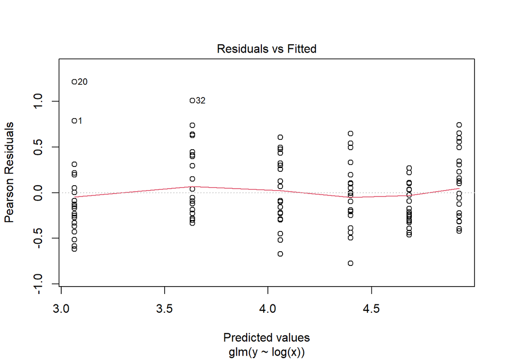

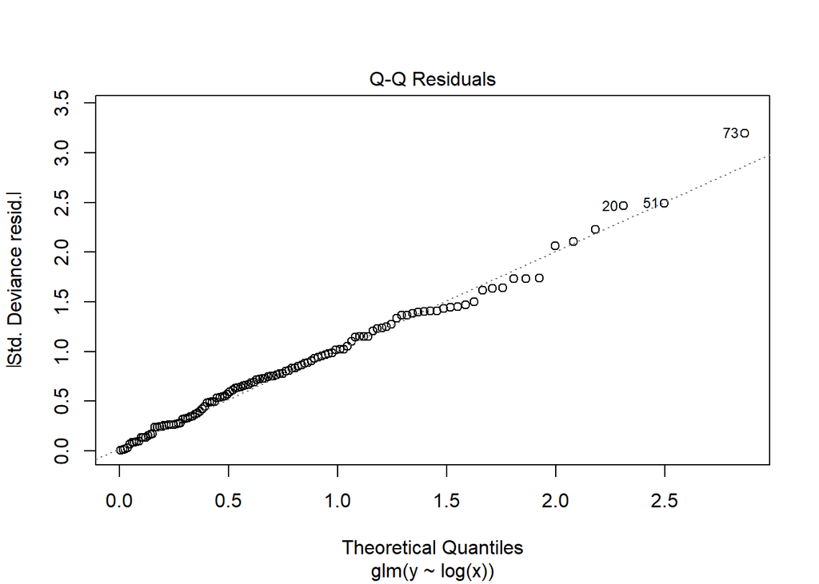

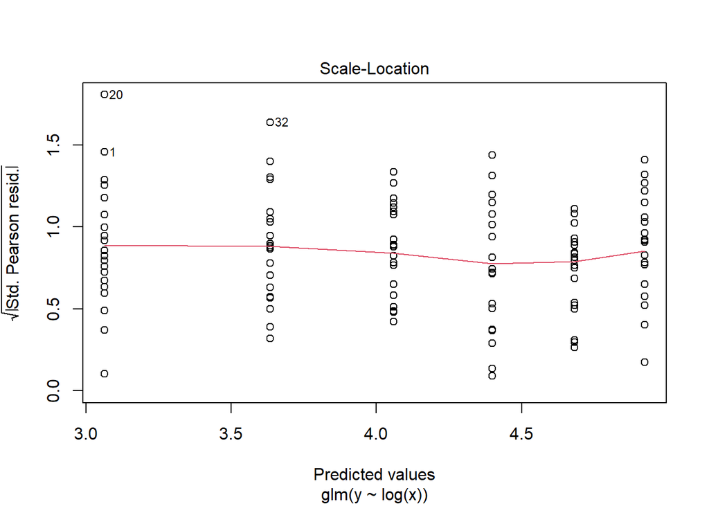

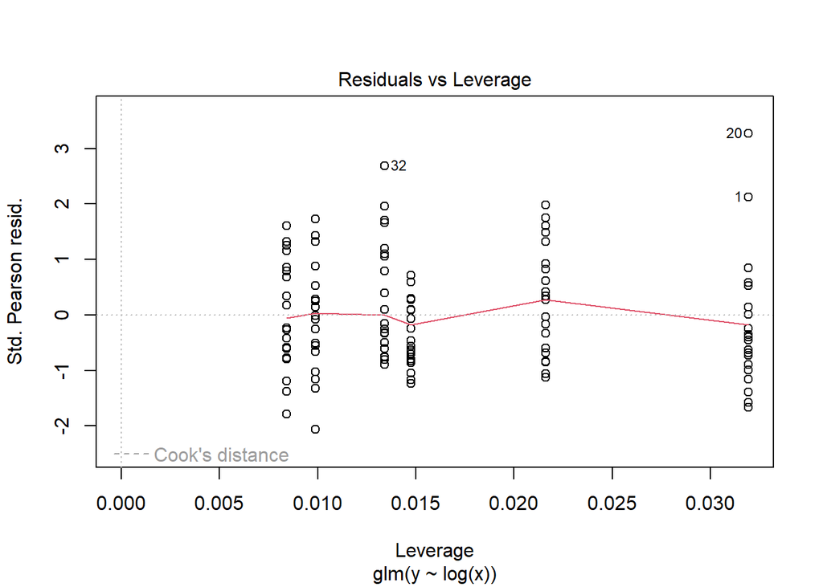

```r
plot(mod3)
```

```r
sum(abs(rstudent(mod3))>2)
```

```
## [1] 6
```